# Análisis de datos ómicos: Segunda Prueba de Evaluación Continua

Carmen Lebrero Cia

1/6/2020

# 1 Introducción y objetivos

La secuenciación de RNA (RNA-seq) es una técnica que ha emergido en los últimos años y que ha revolucionado las herramientas de la transcriptómica. Esta aproximación permite una medida más precisa de los niveles de transcritos y sus isoformas (Wang, Gerstein, and Snyder 2009). La RNA-seq es también utilizada en áreas como la genómica funcional o la biología del cáncer, donde es interesante estudiar niveles de expresión diferentes en condiciones biológicas distintas, por ejemplo el tratamiento o no tratamiento de unas células cancerosas.

A pesar de que el objetivo final de la RNA-seq puede ser el mismo que el de los microarrays, los métodos estadísticos computacionales utilizados para el análisis de los datos para cada una técnicas es distinto. *Bioconductor*, un repositorio de bioinformática, tiene paquetes que han sido desarrollados para el análisis de los archivos count, entre los que destacan: *DESeq*, *DESeq2*, *edgeR*, *baySeq* o *limma*.

Este documento presenta un ejemplo de análisis de RNA-seq realizado con R y Bioconductor. El objetivo de esta PEC es mostrar cómo realizar un proceso de análisis de datos de ultrasecuenciación y un informe dinámico en el que se ilustrará de forma didáctica el pipeline llevado a cabo.

## 1.1 Estructura del documento

La estructura que seguirá el documento será una estructura básica de un trabajo científico organizada en: *Introducción y Objetivos*, *Materiales y Métodos*, *Resultados* y *Discusión*, aunque esta estructura será un poco laxa dado que el objetivo principal de la PEC es demostrar que podemos llevar a cabo el proceso de análisis, es decir, la metodología. Tras una introducción, pasaremos a una descripción del proceso de análisis (*workflow*) y los métodos y programas utilizados. A continuación se presentarán los resultados obtenidos en cada paso del análisis para finalizar con una discusión de los resultados obtenidos y las dificultades encontradas en el trabajo.

## 1.2 Objetivos

El objetivo de este trabajo es realizar un análisis de datos de RNA-seq pertenecientes a un análisis de tejidos de tiroides para encontrar genes diferencialmente expresados en tres tipos de infiltración medidos en un total de 292 muestras pertenecientes a tres grupos: *Not infiltrated tissues* (NIT) con n=236, *Small focal filtrates* (SFI) con n=42 y *Extensive lymphoid infiltrates* (ELI) con n=14.

En este ejercicio se nos proporcionan los datos preprocesados en una tabla de contajes y, para garantizar que los datos de cada alumno son distintos, se pide extraer 30 muestras aleatoriamente, 10 de cada grupo mediante un *script* o código de R. El material de partida son dos archivos, el archivo “targets.csv” y el archivo “counts.csv”. En el archivo targets podremos observar el grupo al que pertenece cada muestra en la columna “groups” y, obteniendo lo índices randomizados para 10 muestras de estos datos, obtener 10 muestras de cada grupo del archivo counts.

Una vez preparados los datos, realizaremos un análisis de expresión diferencial. Dado que hay tres grupos, podrían hacerse tres comparaciones: SFI-NIT, ELI-NIT y ELI-SFI.

Como objetivos secundarios fijamos familiarizarse con el uso del entorno de R/Bioconductor para el análisis estadístico de RNA-seq y mostrar los problemas estadísticos que encontramos en el análisis de datos de secuenciación.

# 2 Materiales y métodos

## 2.1 Etapas del análisis

El análisis se realizará siguiendo el procedimiento descrito en varios materiales facilitados por el profesor y otros encontrados mediante búsqueda bibliográfica entre los que destacan:

- Archivo *RNASeqBiocPipeline.html* en el que se describe el análisis de un RNA-seq utilizando Bioconductor. Este archivo ha sido facilitado por el profesor a través de un repositorio.
- Archivo *Statistical analysis of RNA-seq data.pdf*, facilitado por el profesor.Se trata de un tutorial de Análisis estadístico de datos de RNA-seq
- La página web (“Rna-Seq Workflow: Gene-Level Exploratory Analysis and Differential Expression,” n.d.). Un *workflow* de expresión diferencial de genes a partir de datos de RNA-seq utilizando paquetes de Bioconductor.
- El artículo (Oshlack, Robinson, and Young 2010) que se centra en ejemplos de análisis de RNA-seq que llevan a cabo procedimientos con softwares y metodologías de código abierto.

Si nos fijamos en la Figura 2.1, nosotros empezaríamos nuestro *pipeline* a partir de la *Table of counts*, de ahí realizariamos el proceso de normalización de los datos, crearíamos la lista de genes diferencialmente expresados, llevaríamos a cabo un análisis de significación biológica (análisis de enriquecimiento) y dicutiriamos los resultados obtenidos.

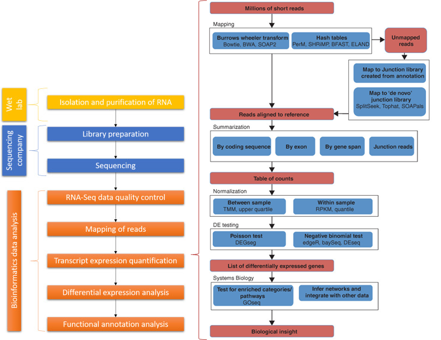

Figure 2.1: Visión general del proceso de detección de expresión diferencial de genes. A la izquierda podemos ver el proceso de forma más amplia y a la derecha el proceso bioinformático de fomra más detallada con cada una de las etapas en rojo y los métodos utilizados en azul (Pobre and Arraiano 2018)(Oshlack, Robinson, and Young 2010).

## 2.2 Métodos de análisis

En este caso no partiremos de los datos crudos devueltos por el secuenciador, es decir, no partiremos de un archivo en el que únicamente encontraremos los fragmentos de lecturas cortas. Por el contrario, partiremos de una matriz de conteos en la que ya tendremos las lecturas mapeadas y tendremos el número de lecturas para cada muestra y cada gen, pero antes realizaremos el muestreo aleatorio que se nos pedía en el enunciado para que cada alumno partiese de unos datos distintos. Construiremos un nuevo objeto que sea adecuado para el análisis posterior (`DESeqDataSet`).

Con este objeto realizaremos la normalización de los datos de conteo con la Transformación de estabilización de varianza (VST). Después exploraremos y visualizaremos los datos mediante Heatmaps de las distancias muestrales, gráficas componentes principales (PCA) y gráficas de escalado multidimensional (MDS).

El análisis de expresión diferencial se realizará con el paquete `DESeq` para seguir con las tablas de resultados y subagrupar los genes más diferencialmente expresados en base al p-valor ajustado o el log-change. Estos resultados se representarán en gráficos para una mejor visualización. Las listas de genes obtenios se anotarán y se intentará realizar un análisis de significación biológica utilizando la base de datos Gene Ontology.

### 2.2.1 Herramientas y procedimientos bioinformáticos de análisis

Los análisis estadísticos se realizaron utilizando el lenguaje R y las librerías desarrolladas para el análisis de microarray en el proyecto de Bioconductor (www.bioconductor.org). El código siguiente se utilizópara instalar los paquetes de Bioconductor necesarios para el análisis:

```r
if(!require(BiocManager)) install.packages("BiocManager")
if(!require(airway)) BiocManager::install("airway")
if(!require(Rsamtools)) BiocManager::install("Rsamtools")
if(!require(GenomicFeatures)) BiocManager::install("GenomicFeatures")
if(!require(DESeq2)) BiocManager::install("DESeq2")
if(!require(apeglm)) BiocManager::install("apeglm")
if(!require(BiocParallel)) BiocManager::install("BiocParallel")
if(!require(genefilter)) BiocManager::install("genefilter")
if(!require(org.Hs.eg.db)) BiocManager::install("org.Hs.eg.db")
if(!require(AnnotationDbi)) BiocManager::install("AnnotationDbi")
if(!require(ReportingTools)) BiocManager::install("ReportingTools")
if(!require(RUVSeq)) BiocManager::install("RUVSeq")
if(!require(sva)) BiocManager::install("sva")
if(!require(Gviz)) BiocManager::install("Gviz")
if(!require(dplyr)) install.packages("dplyr", dep=TRUE)
if(!require(magrittr)) install.packages("magrittr", dep=TRUE)
if(!require(ggplot2)) install.packages("ggplot2", dep=TRUE)
if(!require(pheatmap)) install.packages("pheatmap", dep=TRUE)
if(!require(RColorBrewer)) install.packages("RColorBrewer", dep=TRUE)
if(!require(ggbeeswarm)) install.packages("ggbeeswarm", dep=TRUE)
if(!require(PoiClaClu)) install.packages("PoiClaClu", dep=TRUE)
if(!require(glmpca)) install.packages("glmpca", dep=TRUE)
```

```r
if(!require(tximport)) install.packages("tximport", dep=TRUE)
if(!require(htseq-count)) install.packages("htseq-count", dep=TRUE)
if(!require(featureCounts)) install.packages("featureCounts", dep=TRUE)
if(!require(summarizeOverlaps)) install.packages("summarizeOverlaps", dep=TRUE)
```

# 3 Obtención y lectura de los datos

## 3.1 Los datos para el análisis

Los datos en los que se basan esta PEC se han obtenido a partir de un estudio obtenido del repositorio *Genotype Tissue Expression* (GTEx). Este repositorio se trata de un proyecto para construir una base de datos de investigación de expresión y regulación génica específica de cada tejido, conteniendo datos de 54 tejidos distintos recogidos de 1000 individuos distintos. En esta práctica nos centraremos en datos de expresión (RNA-seq) de un análisis de tiroides en donde se compara tres tipos de infiltración medido en un total de 292 muestras pertenecientes a los tres grupos que hemos citado en la introducción.

## 3.2 Localización de los datos

Como ya hemos estado trabajando durante el curso, escogeremos un directorio en concreto que lo asignaremos como nuestro directorio de trabajo y lo guardaremos en la variable `workingDir`.

A partir de este directorio crearemos 3 subcarpetas: Una carpeta llamada *datos* en la que encontraremos los datos de partida, es decir, los archivos *targets.csv* y *counts.csv*; una carpeta llamada *imagenes*, con las figuras que hayamos puesto en el texto y gráficas creadas en el proceso de análisis y una última carpeta llamada *resultados* en la que guardaremos archivos que se originen en el proceso de análisis.

```r
workingDir <-getwd()
dataDir <- file.path(workingDir, "datos")
resultsDir <- file.path(workingDir,"resultados")
imagDir <- file.path(workingDir,"imagenes")
setwd(workingDir)
```

Estos pasos los podemos realizar dentro de la consola de comandos de R o mediante el explorador de archivos de windows. En github podremos encontrar un repositorio con todos los archivos iniciales y creados a lo largo del análisis: https://github.com/crmnlc/PEC2_ADO.

## 3.3 Selección de muestras para el análisis

Este estudio se basa en un subconjunto de muestras del estudio original, cogiendo únicamente 10 muestras para cada grupo. Las muestras se han obtenido de los archivos originales de targets y counts mediante un script de R.

Lo primero que tenemos que hacer es abrir los dos archivos originales y, a partir de los datos del archivo targets fijarnos en la columna *groups* y así podemos saber el grupo de muestras al que pertenece y realizas un subconjunto con cada grupo. Los dos archivos tienen en común que las 292 variables del archivo counts (las columnas) tienen el mismo nombre que la variable “Sample_name” del archivo targets.

```r
# Importamos los archivos originales de targets y counts

targets <- read.csv(file.path(dataDir, "targets.csv"), header=TRUE, row.names=1, sep=",", stringsAsFactors=FALSE)
counts <- read.csv(file.path(dataDir, "counts.csv"), header=TRUE, row.names=1, sep=";", stringsAsFactors=FALSE)

# Realizamos subconjuntos del archivo targets basándonos en la variable Group

NIT <- subset(targets, targets$Group == "NIT")
ELI <- subset(targets, targets$Group == "ELI")
SFI <- subset(targets, targets$Group == "SFI")

# Llevamos a cabo el muestreo aleatorio para cada una de las muestras. Obtendremos vectores tipo char con 10 nombres de muestras de cada grupo.

set.seed(123)
NIT_10 <- sample(NIT$Sample_Name, 10, replace = FALSE)
ELI_10 <- sample(ELI$Sample_Name, 10, replace = FALSE)
SFI_10 <- sample(SFI$Sample_Name, 10, replace = FALSE)

# Si nos fijamos en los vectores de nombre de muestra no son realmente idénticos puesto que los nombres del archivo targets estaban guionizados, mientras que los nombres del archivo counts tienen un ".". Tendremos

colnames(counts) <- gsub("\\.", "-", colnames(counts))

# Función para obtener tres datasets, uno por cada grupo, con los datos de counts para las 10 muestras que hemos obtenido al azar.

dataNIT <- counts[, colnames(counts) %in% NIT_10]
dataELI <- counts[, colnames(counts) %in% ELI_10]
dataSFI <- counts[, colnames(counts) %in% SFI_10]

# Ahora juntamos los tres Dataframes y lo guardamos en un archivo llamado "countsnew"

countsnew <- cbind(dataNIT,dataELI)
countsnew <- cbind(countsnew, dataSFI)

# Tenemos que coger del archivo targets solo los datos y juntarlos en el mismo Dataframe

targetsNIT <- targets[targets$Sample_Name %in% NIT_10,]
targetsELI <- targets[targets$Sample_Name %in% ELI_10,]
targetsSFI <- targets[targets$Sample_Name %in% SFI_10,]
targetsnew <- rbind(targetsNIT,targetsELI)
targetsnew <- rbind(targetsnew, targetsSFI)
```

Finalmente obtenemos dos archivos nuevos, `targetsnew` y `countsnew`.

```r
# Guardaremos estos archivos generados en la carpeta de resultados.

write.csv(countsnew, file=file.path(resultsDir, "counts_new.csv"))
write.csv(targetsnew, file=file.path(resultsDir, "targets_new.csv"))
```

## 3.4 Lectura de los datos

Comenzaremos este análisis a partir de los dos archivos construídos en el paso anterior, es decir, a partir de la matriz de conteos y la tabla con la informació de cada muestra. Vamos a echar un vistazo a nuestra tabla con la información de cada muestra y a nuestra matriz de conteos (Ver 3.1 y 3.2, respectivamente).

Podemos observar que en la **matriz de conteos**, cada fila representa un gen y cada columna una muestra específica. Los valores numéricos que encontramos se refieren al número de fragmentos que se asignan a un gen específico en cada librería.

Table 3.1: Tabla de información de cada muestra para las 5 primeras muestras

|  | SRA_Sample | Sample_Name | Grupo_analisis | body_site | molecular_data_type | sex | Group | ShortName |
| --- | --- | --- | --- | --- | --- | --- | --- | --- |
| SRX579805 | SRS629854 | GTEX-11DZ1-2726-SM-5A5KH | 1 | Thyroid | Allele-Specific Expression | male | NIT | 11DZ1_NIT |
| SRX631448 | SRS648534 | GTEX-12WSN-0726-SM-5GCMS | 1 | Thyroid | Allele-Specific Expression | male | NIT | 12WSN_NIT |
| SRX571829 | SRS627809 | GTEX-131XH-0526-SM-5DUX7 | 1 | Thyroid | Allele-Specific Expression | male | NIT | 131XH_NIT |
| SRX595510 | SRS636352 | GTEX-14ASI-0726-SM-5Q5DC | 1 | Thyroid | RNA Seq (NGS) | male | NIT | 14ASI_NIT |
| SRX221539 | SRS389105 | GTEX-S7SE-0726-SM-2XCD7 | 1 | Thyroid | RNA Seq (NGS) | male | NIT | S7SE-_NIT |

Table 3.2: Matriz de conteos del estudio en la que aparecen los 5 primeros genes y las 5 primeras muestras

|  | GTEX-11DZ1-2726-SM-5A5KH | GTEX-12WSN-0726-SM-5GCMS | GTEX-131XH-0526-SM-5DUX7 | GTEX-14ASI-0726-SM-5Q5DC | GTEX-S7SE-0726-SM-2XCD7 |
| --- | --- | --- | --- | --- | --- |
| ENSG00000223972.4 | 0 | 1 | 0 | 0 | 4 |
| ENSG00000227232.4 | 525 | 481 | 766 | 1246 | 422 |
| ENSG00000243485.2 | 0 | 0 | 1 | 0 | 0 |
| ENSG00000237613.2 | 1 | 1 | 2 | 0 | 1 |
| ENSG00000268020.2 | 0 | 2 | 0 | 0 | 1 |

Es muy importante en este proceso que el orden en el que aparecen las muestras en la matriz de conteos sea el mismo orden en el que aparecen las muestras en la tabla de información de muestras.

```r
colnames(countsnew) == targetsnew$Sample_Name
```

```
##  [1] TRUE TRUE TRUE TRUE TRUE TRUE TRUE TRUE TRUE TRUE TRUE TRUE TRUE TRUE TRUE
## [16] TRUE TRUE TRUE TRUE TRUE TRUE TRUE TRUE TRUE TRUE TRUE TRUE TRUE TRUE TRUE
```

Así podemos confirmar que el orden coincide. Ya tenemos todos los archivos necesarios para crear el objeto `DESeqDataSet`que nos permitirá un mejor análisis de los datos, para ello utilizaremos la función `DESeqDataSetFromMatrix`.

```r
ddsMat <- DESeqDataSetFromMatrix(countData = countsnew,
                                  colData = targetsnew,
                                  design = ~ Group)
ddsMat
```

```
## class: DESeqDataSet
## dim: 56202 30
## metadata(1): version
## assays(1): counts
## rownames(56202): ENSG00000223972.4 ENSG00000227232.4 ...
##   ENSG00000210195.2 ENSG00000210196.2
## rowData names(0):
## colnames(30): SRX579805 SRX631448 ... SRX221390 SRX577086
## colData names(8): SRA_Sample Sample_Name ... Group ShortName
```

# 4 Preprocesado: Exploración, Control de Calidad y Normalización

En este apartado realizaremos uno de los pasos más importantes para el análisis estadístico, el control de calidad y la exploración de los datos. Este proceso se suele lleva a cabo al inicio del análisis antes o al mismo tiempo que la normalización de los datos y los test de expresión diferencial.

Este paso lo podemos dividir en dos partes: Una primera parte de transformaciones de los conteos para explorar de forma gráfica relaciones entre muestras y una segunda parte de visualización de los datos sin normalizar para las pruebas estadísticas. El objetivo es encontrar muestras que produzcan puntos en nuestro análisis que sean perjudiciales y puedan llevarnos a errores en nuestra búsqueda de genes diferencialmente expresados.

## 4.1 Normalización y Filtraje

### 4.1.1 Prefiltrado de la base de datos

La matriz de conteos, y por tanto el archivo *DESeqDataSet*, presenta varias filas nulas o con pocos fragmentos por muestra/gen. Con el objetivo de disminuir el tamaño del objeto, optimizar el análisis, y reducir el tiempo de ejecución de las funciones, eliminaremos los valores de la matriz de conteos que no nos aporten información relevante sobre la expresión génica, es decir las filas de *DESeqDataSet* que no tengan o tengan pocos conteos.

```r
# Número de filas que tiene el archivo DESeqDataSet
nrow(ddsMat)
```

```
## [1] 56202
```

```r
# Subconjunto de DESeqDataSet, quedándonos con las filas con sumatorio de conteos mayores a 1 y guardamos este cambio en el objeto.
keep <- rowSums(counts(ddsMat)) > 1
ddsMat <- ddsMat[keep,]
nrow(ddsMat)
```

```
## [1] 43186
```

Pasamos de tener un objeto con 56202 filas a un objeto con 43186 filas.

### 4.1.2 Transformación de estabilización de varianza (VST) y rlog

Muchos métodos estadísticos de visualización y exploración de datos trabajan mejor con versiones de los datos de conteos que han sido transformados. La distribución de los datos de la matriz de conteos está bastante sesgada debido a que los genes con más conteos muestran diferencias más grandes entre muestras, es por ello que una transformación de los datos ayuda a normalizar la distribución. Estos datos podemos transformarlos con distintos métodos entre los que destacan *VST*, *rlog* o *log2* pero, ¿qué transformación debemos escoger? En nuestro caso utilizaremos la transformación VST, aunque *rlog* es también válida. Esto es debido a que a diferencia de la transformación *log2* en la que los genes con pocos conteos (parte baja-izquierda de la gráfica) son muy variables, en las gráficas de *rlog* y *VST* estos genes aportan menor información sobre la expresión diferencial (Ver Figura 4.1) .

```r
vsd <- vst(ddsMat, blind = FALSE)
head(assay(vsd), 3)
```

```
##                   SRX579805 SRX631448 SRX571829 SRX595510 SRX221539 SRX260951
## ENSG00000223972.4  4.168732  4.529947  4.168732  4.168732  4.891515  4.168732
## ENSG00000227232.4  9.312330  9.181289  9.838842  9.915038  9.026918  9.124198
## ENSG00000243485.2  4.168732  4.168732  4.532423  4.168732  4.168732  4.168732
##                   SRX407742 SRX590541 SRX577234 SRX591390 SRX563960 SRX619829
## ENSG00000223972.4  4.463502  5.122265  4.819006  4.949327  4.518738  4.168732
## ENSG00000227232.4  9.718547  9.380449  9.702732  9.762504  9.075731  8.919403
## ENSG00000243485.2  4.463502  4.750312  4.546275  4.666002  4.518738  4.168732
##                   SRX582762 SRX601511 SRX575932 SRX607358 SRX199272 SRX204036
## ENSG00000223972.4  4.168732  4.168732  4.473797  4.168732  4.840273  5.209964
## ENSG00000227232.4  9.617089  9.842755  9.368595  9.919748  8.725350  8.883307
## ENSG00000243485.2  4.462489  4.519736  4.599363  4.527609  4.471218  4.778472
##                   SRX222429 SRX583148 SRX616143 SRX576955 SRX600771 SRX596173
## ENSG00000223972.4  4.649323  4.711575  4.907909  4.786241  4.506667  5.008646
## ENSG00000227232.4  9.436384  9.796160  9.629279  8.995510 10.090701  9.745196
## ENSG00000243485.2  4.649323  4.441352  4.168732  4.527057  4.645564  4.548582
##                   SRX597654 SRX561460 SRX199518 SRX203531 SRX221390 SRX577086
## ENSG00000223972.4  4.681829  4.854551  4.508247  4.805210  4.629078  4.665677
## ENSG00000227232.4  9.048876  9.001203  9.830024  9.382761 10.083007  9.874401
## ENSG00000243485.2  4.168732  4.783282  5.114231  4.538180  4.435263  4.520989
```

```r
rld <- rlog(ddsMat, blind = FALSE)
```

```
## rlog() may take a few minutes with 30 or more samples,
## vst() is a much faster transformation
```

```r
head(assay(rld), 3)
```

```
##                    SRX579805  SRX631448 SRX571829 SRX595510  SRX221539
## ENSG00000223972.4 0.78492609 0.95072188 0.7853043 0.7548777 1.33668538
## ENSG00000227232.4 9.27469875 9.17292761 9.6858126 9.7458600 9.05332950
## ENSG00000243485.2 0.05140364 0.05103298 0.2134445 0.0352430 0.05173105
##                    SRX260951 SRX407742 SRX590541 SRX577234 SRX591390 SRX563960
## ENSG00000223972.4 0.75889557 0.8825095 1.6428550 1.2485369 1.4097557 0.9393607
## ENSG00000227232.4 9.12838274 9.5917001 9.3276091 9.5791439 9.6260030 9.0910356
## ENSG00000243485.2 0.03738245 0.1559583 0.4388093 0.2248652 0.3380152 0.2020916
##                    SRX619829 SRX582762 SRX601511 SRX575932 SRX607358 SRX199272
## ENSG00000223972.4 0.77995937 0.7550482 0.7798579 0.8931732 0.7832420 1.2865545
## ENSG00000227232.4 8.97007995 9.5123019 9.6889234 9.3183888 9.7493396 8.8197474
## ENSG00000243485.2 0.04870786 0.1551132 0.2029214 0.2758653 0.2094582 0.1624003
##                   SRX204036 SRX222429 SRX583148  SRX616143 SRX576955 SRX600771
## ENSG00000223972.4 1.6167331 1.0625630 1.1343400 1.35441629  1.213626 0.9270423
## ENSG00000227232.4 8.9456468 9.3711992 9.6525814 9.52172011  9.028984 9.8839260
## ENSG00000243485.2 0.3798734 0.3292358 0.1375605 0.05368107  0.209000 0.3190562
##                   SRX596173  SRX597654 SRX561460 SRX199518 SRX203531 SRX221390
## ENSG00000223972.4 1.4745161 1.09741519 1.3029661 0.9286589 1.2339072 1.0397646
## ENSG00000227232.4 9.6123743 9.07032186 9.0330513 9.6789712 9.3294896 9.8781386
## ENSG00000243485.2 0.2267588 0.05162652 0.4731986 0.8595506 0.2182001 0.1325403
##                   SRX577086
## ENSG00000223972.4 1.0805332
## ENSG00000227232.4 9.7137534
## ENSG00000243485.2 0.2039636
```

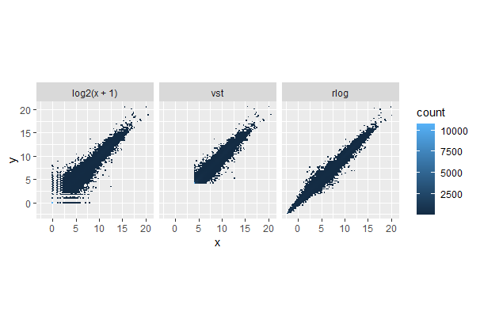

Figure 4.1: Gráficos de distribución de los datos transformados.

```r
library("dplyr")
library("ggplot2")

ddsMat <- estimateSizeFactors(ddsMat)

df <- bind_rows(
  as.data.frame(log2(counts(ddsMat, normalized=TRUE)[, 1:2]+1)) %>%
         mutate(transformation = "log2(x + 1)"),
  as.data.frame(assay(vsd)[, 1:2]) %>% mutate(transformation = "vst"),
  as.data.frame(assay(rld)[, 1:2]) %>% mutate(transformation = "rlog"))

colnames(df)[1:2] <- c("x", "y")

lvls <- c("log2(x + 1)", "vst", "rlog")
df$transformation <- factor(df$transformation, levels=lvls)
ggplot(df, aes(x = x, y = y)) + geom_hex(bins = 80) +
  coord_fixed() + facet_grid( . ~ transformation)
```

## 4.2 Exploración y visualización

### 4.2.1 Exploración estadística de los datos

#### 4.2.1.1 Distancias muestrales

Una primera aproximación para el análisis de RNA-seq es observar la similitud general entre muestras, para ello podemos utilizar la función `dist()`de R, que nos permite calcular la distancia Euclidea entre muestras. Este abordaje lo realizaremos con los datos transformados por el método VST para estar seguros que hay una contribución equivalente de todos los genes.

```r
sampleDists <- dist(t(assay(vsd)))
sampleDists
```

Podemos visualizar las distancias en un *heatmap* en la Figura 4.2, utilizando la función *pheatmap* del paquete *pheatmap*. En esta figura hemos cambiado los nombres de las filas de la matriz de distancias por el Shortname de la muestra en el que aparece también el grupo al que pertenece la muestra.

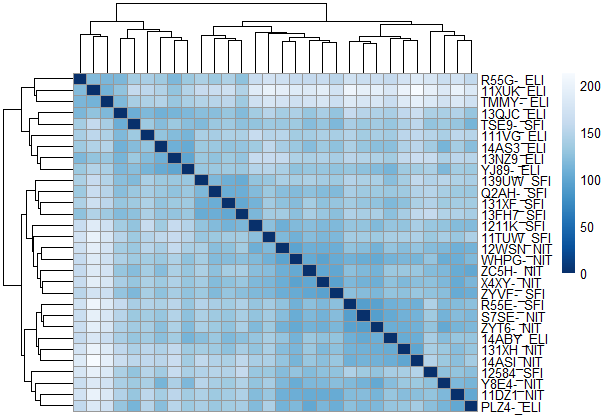

Figure 4.2: Heatmap de distancias muestra-muestra utilizando los valores transformados por VST.

```r
library("pheatmap")
library("RColorBrewer")
sampleDistMatrix <- as.matrix(sampleDists)
rownames(sampleDistMatrix) <-  vsd$ShortName
colnames(sampleDistMatrix) <- NULL
colors <- colorRampPalette( rev(brewer.pal(9, "Blues")) )(255)
library("pheatmap")
library("RColorBrewer")
sampleDistMatrix <- as.matrix( sampleDists )
rownames(sampleDistMatrix) <-  vsd$ShortName
colnames(sampleDistMatrix) <- NULL
colors <- colorRampPalette( rev(brewer.pal(9, "Blues")) )(255)
pheatmap(sampleDistMatrix,
         clustering_distance_rows = sampleDists,
         clustering_distance_cols = sampleDists,
         col = colors)
```

Otra opción para calcular las distancias entre muestras es la *Distancia de Poisson* con el paquete `PoiClaClu`. En este caso no es necesario que utilicemos los datos transformados por VST puesto que ya tiene en consideración la varianza inherente a los conteos. Esta distancia utiliza los datos de la matriz de conteos original. Podemos observar el Heatmap creado en la Figura 4.3.

```r
library("PoiClaClu")
poisd <- PoissonDistance(t(counts(ddsMat)))
```

[figure not shown]

Figure 4.3: Heatmap de distancias muestra-muestra utilizando la distancia de Poisson.

```r
samplePoisDistMatrix <- as.matrix( poisd$dd )
rownames(samplePoisDistMatrix) <- ddsMat$ShortName
colnames(samplePoisDistMatrix) <- NULL
pheatmap(samplePoisDistMatrix,
         clustering_distance_rows = poisd$dd,
         clustering_distance_cols = poisd$dd,
         col = colors)
```

#### 4.2.1.2 Gráficos PCA

Otra manera de visualizar las diferencias entre muestras es el **Análisis de componentes principales** (PCA). Con este método las muestras se pyectan en un plano 2D y se esparcen en dos direcciones que explican la mayoría de las diferencias entre ellas. En este espacio, el eje x es la dirección que más separa los puntos entre sí, es el eje de la primera componente (PC1). En el eje y tendremos la segunda dirección que separa más los datos, PC2. El porcentaje de varianza total se encuentra en cada eje. En el caso de nuestro estudio, una de las variables que más va a explicar la varianza entre muestras es el grupo al que pertenece la muestra y la otra variable podría ser el sexo del individuo.

En la Figura 4.4 podemos ver que la mayoría de muestras sí que parece ordenarse en clusters de muestras con el mismo grupo y sexo, por ejemplo, vemos todas las muestras de NIT:male cercanas, al igual que las de ELI:male y las de ELI:female (a excepción de una). También es cierto que algunos grupos se quedan sin apenas representación debido a que las muestras se eligieron al azar teniendo en cuenta el grupo y no el sexo del individuo. Por otra parte podemos decir que la variable del grupo, componente principal, es la responsable de un 58% de la varianza entre muestras, mientras que el sexo es solamente responsable del 9% de varianza.

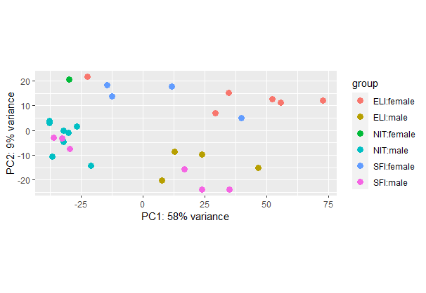

Figure 4.4: Gráfico PCA utilizando los datos de VST.

```r
plotPCA(vsd, intgroup = c("Group", "sex"))
```

### 4.2.2 Gráficos PCA con Análisis de componentes principales generalizadas

Otra técnica que se usa para datos que no siguen una distribución normal es el análisis de componentes principales generalizadas (GLM-PCA), implementada en el paquete *glmpca*. Este paquete utiliza como input la matriz de conteos y el número de dimensiones que queremos utilizar.

En la figura 4.5 podemos encontrar este gráfico. Lo interesante en este caso sería que todos los puntos del mismo color se encontrasen más o menos cercanos en la gráfica. Las muestras de ELI parecen más agrupadas a excepción de dos muestras, independientemente del sexo del individuo. El resto de grupos parecen estar más dispersos.

```r
library("glmpca")
gpca <- glmpca(counts(ddsMat), L=2)
gpca.dat <- gpca$factors
gpca.dat$Group <- ddsMat$Group
gpca.dat$sex <- ddsMat$sex
```

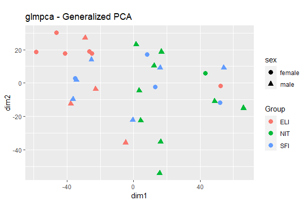

Figure 4.5: Gráfico GLM-PCA utilizando los datos sin normalizar.

```r
ggplot(gpca.dat, aes(x = dim1, y = dim2, color = Group, shape = sex)) +
  geom_point(size =3) + coord_fixed() + ggtitle("glmpca - Generalized PCA")
```

#### 4.2.2.1 Gráfica de escalado multidimensinal

Este tipo de gráficas son útiles cuando solo tenemos una matriz de distancias. Construiremos este gráfico para las distancias calculadas de los datos normalizados por el método *VST*. El gráfico MDS para los datos normalizados mediante *VST* lo podemos ver en la Figura 4.6 y parece que las muestras del mismo Grupo tienden a estar juntas. En la Figura 4.7 se muestra la misma gráfica pero utilizando la distancia de Poisson.

```r
mds <- as.data.frame(colData(vsd))  %>%
         cbind(cmdscale(sampleDistMatrix))
ggplot(mds, aes(x = `1`, y = `2`, color = Group, shape = sex)) +
  geom_point(size = 3) + coord_fixed() + ggtitle("MDS with VST data")
```

[figure not shown]

Figure 4.6: Gráfico MDS utilizando los datos de VST.

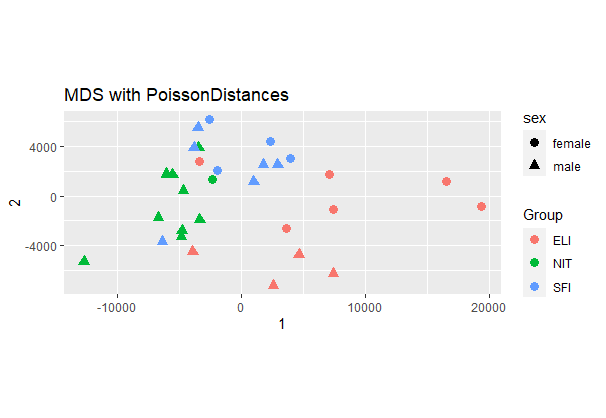

Figure 4.7: Gráfico MDS usando las distancias de Poisson.

```r
mdsPois <- as.data.frame(colData(ddsMat)) %>%
   cbind(cmdscale(samplePoisDistMatrix))
ggplot(mdsPois, aes(x = `1`, y = `2`, color = Group, shape = sex)) +
  geom_point(size = 3) + coord_fixed() + ggtitle("MDS with PoissonDistances")
```

# 5 Análisis de expresión diferencial

## 5.1 Ejecutando el pipeline de expresión diferencial

El análisis de expresión diferencial se puede ejecutar con la función `DESeq` de forma sencilla utilizando como input nuestro archivo `ddsMat`. Esto es debido a que el diseño experimental lo hemos específicado a la hora de crear el archivo *DESeqDataSet* con la opción `desing = ~ Group`. La función `DESeq` imprimirá un mensaje por cada paso del análisis que esté realizando, entre estos pasos tenemos:

- Estimación del tamaño de los factores
- Estimación de los valores de dispersión para cada gen
- Ajuste de un modelo lineal

Esta función devuelve un archivo *DESeqDataSet* con todos los parámetros ajustados. En los siguientes apartados veremos cómo extraer las tablas con resultados de interés.

```r
ddsMat <- DESeq(ddsMat)
```

```
## -- replacing outliers and refitting for 310 genes
## -- DESeq argument 'minReplicatesForReplace' = 7
## -- original counts are preserved in counts(dds)
```

## 5.2 Construyendo la tabla de resultados

En el enunciado de esta PEC se nos pedía que hiciesemos tres comparaciones, dado que había tres grupos: SFI-NIT, ELI-NIT y ELI-SFI. Podemos producir la tabla de resultados para cada comparación utilizando la función `results` y un comando con argumentos que especifiquen que queremos fijarnos en la variable *Group* del diseño experimental y entre qué niveles queremos realizar la comparación.

**SFI-NIT**

```r
resSFI_NIT <- results(ddsMat, contrast=c("Group","SFI","NIT"))
resSFI_NIT
```

```
## log2 fold change (MLE): Group SFI vs NIT
## Wald test p-value: Group SFI vs NIT
## DataFrame with 43186 rows and 6 columns
##                            baseMean    log2FoldChange             lfcSE
##                           <numeric>         <numeric>         <numeric>
## ENSG00000223972.4  2.47995418775223 0.340332141944805 0.744869856319537
## ENSG00000227232.4  701.719983020983 0.100474109637331 0.190624395547825
## ENSG00000243485.2  1.30461459100484  1.15954812172988 0.813552906660965
## ENSG00000237613.2  1.22368954671618 0.200190234120778 0.861255934845954
## ENSG00000268020.2  0.68089873215097 -0.42505629340237  1.27206977390244
## ...                             ...               ...               ...
## ENSG00000198695.2  46382.8399944217  1.34517135065835 0.582694710795875
## ENSG00000210194.1  16.7781096800843  1.50302109553758 0.857220895467718
## ENSG00000198727.2  398006.498811971 0.288748451388738 0.372951239495332
## ENSG00000210195.2 0.512062033975732 0.241854458209181  1.75824604084721
## ENSG00000210196.2  2.54252525630275 0.664015786450215 0.982494931347399
##                                 stat             pvalue              padj
##                            <numeric>          <numeric>         <numeric>
## ENSG00000223972.4  0.456901482933427  0.647741858067923 0.850850138354263
## ENSG00000227232.4  0.527078967771064  0.598138751585624  0.82446721244624
## ENSG00000243485.2   1.42528913883299  0.154073638417134                NA
## ENSG00000237613.2  0.232439889260774  0.816196370025948                NA
## ENSG00000268020.2 -0.334145423563039  0.738269824919494                NA
## ...                              ...                ...               ...
## ENSG00000198695.2   2.30853537150019 0.0209693778435125 0.182973766446164
## ENSG00000210194.1   1.75336497685057 0.0795393787236314 0.337285133637189
## ENSG00000198727.2  0.774225745380187   0.43879730600425 0.721277688777013
## ENSG00000210195.2  0.137554388060867  0.890592605800804                NA
## ENSG00000210196.2  0.675846526291571  0.499138091389493  0.76367576766795
```

**ELI-NIT**

```r
resELI_NIT <- results(ddsMat, contrast=c("Group","ELI","NIT"))
resELI_NIT
```

```
## log2 fold change (MLE): Group ELI vs NIT
## Wald test p-value: Group ELI vs NIT
## DataFrame with 43186 rows and 6 columns
##                            baseMean     log2FoldChange             lfcSE
##                           <numeric>          <numeric>         <numeric>
## ENSG00000223972.4  2.47995418775223 -0.503102515735357 0.779613735606044
## ENSG00000227232.4  701.719983020983 -0.116443132588543 0.190808797576454
## ENSG00000243485.2  1.30461459100484  0.407390154619697 0.851349357586551
## ENSG00000237613.2  1.22368954671618 -0.345115558586955 0.891558431843257
## ENSG00000268020.2  0.68089873215097  0.759645358030385   1.1922993711407
## ...                             ...                ...               ...
## ENSG00000198695.2  46382.8399944217   1.11999729187215 0.582695299425726
## ENSG00000210194.1  16.7781096800843   1.22289675224956 0.858835934874658
## ENSG00000198727.2  398006.498811971  0.454593122615702 0.372951160329872
## ENSG00000210195.2 0.512062033975732  0.120723976867341  1.75255821674349
## ENSG00000210196.2  2.54252525630275  0.865376038076136 0.978086531138961
##                                 stat             pvalue              padj
##                            <numeric>          <numeric>         <numeric>
## ENSG00000223972.4 -0.645322796094995  0.518718022915211 0.753997566629743
## ENSG00000227232.4 -0.610260816416946  0.541689048858863 0.769826659905414
## ENSG00000243485.2  0.478522889562738  0.632278086701446 0.827332256329904
## ENSG00000237613.2 -0.387092473427057  0.698687749462377 0.865380968475597
## ENSG00000268020.2  0.637126359719218  0.524042539849496                NA
## ...                              ...                ...               ...
## ENSG00000198695.2     1.922097694929 0.0545934660743892 0.215336206216138
## ENSG00000210194.1   1.42390030806994  0.154475332640796 0.399767741273549
## ENSG00000198727.2    1.2189079187034  0.222879143801117 0.488633496226966
## ENSG00000210195.2 0.0688844317489572  0.945081610745557                NA
## ENSG00000210196.2  0.884764292857018  0.376283771579206 0.641609923209443
```

**ELI-SFI**

```r
resELI_SFI <- results(ddsMat, contrast=c("Group","ELI","SFI"))
resELI_SFI
```

```
## log2 fold change (MLE): Group ELI vs SFI
## Wald test p-value: Group ELI vs SFI
## DataFrame with 43186 rows and 6 columns
##                            baseMean     log2FoldChange             lfcSE
##                           <numeric>          <numeric>         <numeric>
## ENSG00000223972.4  2.47995418775223 -0.843434657680162 0.770281180191738
## ENSG00000227232.4  701.719983020983 -0.216917242225873  0.19079282309806
## ENSG00000243485.2  1.30461459100484 -0.752157967110188 0.774132391516479
## ENSG00000237613.2  1.22368954671618 -0.545305792707733 0.883174134979036
## ENSG00000268020.2  0.68089873215097   1.18470165143275  1.21332862949883
## ...                             ...                ...               ...
## ENSG00000198695.2  46382.8399944217   -0.2251740587862 0.582691025617525
## ENSG00000210194.1  16.7781096800843 -0.280124343288023 0.849458257500865
## ENSG00000198727.2  398006.498811971  0.165844671226964 0.372951043067482
## ENSG00000210195.2 0.512062033975732  -0.12113048134184  1.75044140616155
## ENSG00000210196.2  2.54252525630275  0.201360251625921 0.957379838259495
##                                  stat            pvalue              padj
##                             <numeric>         <numeric>         <numeric>
## ENSG00000223972.4   -1.09496983617101  0.27352985152943 0.548478739694338
## ENSG00000227232.4   -1.13692558610754 0.255569395034068 0.527727206224986
## ENSG00000243485.2  -0.971614126153222 0.331242552261844                NA
## ENSG00000237613.2  -0.617438590092629 0.536945474942341                NA
## ENSG00000268020.2   0.976406245290776  0.32886318784664                NA
## ...                               ...               ...               ...
## ENSG00000198695.2  -0.386438178874585 0.699172179277077 0.865024867284766
## ENSG00000210194.1  -0.329768226766267 0.741575096983661 0.887568707165205
## ENSG00000198727.2   0.444682148796018 0.656549471607111 0.839952742334906
## ENSG00000210195.2 -0.0691999634580518 0.944830452195839                NA
## ENSG00000210196.2   0.210324307635297  0.83341456481755 0.932846823504907
```

Estos archivos `res` son *Dataframes*, por lo que podemos ver el significado de cada una de las columnas.

```r
mcols(resSFI_NIT, use.names = TRUE)
```

```
## DataFrame with 6 rows and 2 columns
##                        type                               description
##                 <character>                               <character>
## baseMean       intermediate mean of normalized counts for all samples
## log2FoldChange      results  log2 fold change (MLE): Group SFI vs NIT
## lfcSE               results          standard error: Group SFI vs NIT
## stat                results          Wald statistic: Group SFI vs NIT
## pvalue              results       Wald test p-value: Group SFI vs NIT
## padj                results                      BH adjusted p-values
```

La columna `baseMean`, es una media de los valores de conteos normalizados divididos por el tamaño de los factores, sobre todas las muestras en *DESeqDataSet*. Las columnas restantes se refieren al contraste en específico. La columna `log2FoldChange` es el efecto de muestra estimado, es decir, cuánto parece haber cambiado la expresión génica debido al grupo al que pertenece la muestra o tipo de infiltración. Este valor tiene una incertidumbre que se ve reflejada en la columna `lfcSE`. Uno de los estadísticos más importantes aquí es el `pvalue` que nos indica la probabilidad de que un fold change igual o mayor al observado se de en la situación descrita por la hipótesis nula.

Podemos resumir los resultados de las tres comparaciones con el siguiente código:

**SFI-NIT**

```r
summary(resSFI_NIT)
```

```
##
## out of 43182 with nonzero total read count
## adjusted p-value < 0.1
## LFC > 0 (up)       : 982, 2.3%
## LFC < 0 (down)     : 676, 1.6%
## outliers [1]       : 0, 0%
## low counts [2]     : 15911, 37%
## (mean count < 2)
## [1] see 'cooksCutoff' argument of ?results
## [2] see 'independentFiltering' argument of ?results
```

**ELI-NIT**

```r
summary(resELI_NIT)
```

```
##
## out of 43182 with nonzero total read count
## adjusted p-value < 0.1
## LFC > 0 (up)       : 3573, 8.3%
## LFC < 0 (down)     : 1486, 3.4%
## outliers [1]       : 0, 0%
## low counts [2]     : 12562, 29%
## (mean count < 1)
## [1] see 'cooksCutoff' argument of ?results
## [2] see 'independentFiltering' argument of ?results
```

**ELI-SFI**

```r
summary(resELI_SFI)
```

```
##
## out of 43182 with nonzero total read count
## adjusted p-value < 0.1
## LFC > 0 (up)       : 3112, 7.2%
## LFC < 0 (down)     : 1640, 3.8%
## outliers [1]       : 0, 0%
## low counts [2]     : 14237, 33%
## (mean count < 2)
## [1] see 'cooksCutoff' argument of ?results
## [2] see 'independentFiltering' argument of ?results
```

Dado que este análisis lo hemos realizado con un nivel de FDR del 10%, observamos muchos genes con expresión diferencial. Hay dos maneras de ser más restrictivo en cuanto a qué genes considerar significativos:

Bajar el umbral del FDR:

**SFI-NIT**

```r
resSFI_NIT.05  <- results(ddsMat, contrast=c("Group","SFI","NIT"), alpha = 0.05)
table(resSFI_NIT.05$padj < 0.05)
```

```
##
## FALSE  TRUE
## 25563   875
```

**ELI-NIT**

```r
resELI_NIT.05  <- results(ddsMat, contrast=c("Group","ELI","NIT"), alpha = 0.05)
table(resELI_NIT.05$padj < 0.05)
```

```
##
## FALSE  TRUE
## 26962  3662
```

**ELI-SFI**

```r
resELI_SFI.05  <- results(ddsMat, contrast=c("Group","ELI","SFI"), alpha = 0.05)
table(resELI_SFI.05$padj < 0.05)
```

```
##
## FALSE  TRUE
## 25420  3529
```

O elevar el valor del umbral del log2 fold change:

**SFI-NIT**

```r
resSFI_NITLFC1 <- results(ddsMat, contrast=c("Group","SFI","NIT"), lfcThreshold=1)
table(resSFI_NITLFC1$padj < 0.1)
```

```
##
## FALSE  TRUE
## 38829   167
```

**ELI-NIT**

```r
resELI_NITLFC1 <- results(ddsMat, contrast=c("Group","ELI","NIT"), lfcThreshold=1)
table(resELI_NITLFC1$padj < 0.1)
```

```
##
## FALSE  TRUE
## 29807   817
```

**ELI-SFI**

```r
resELI_SFILFC1 <- results(ddsMat, contrast=c("Group","ELI","SFI"), lfcThreshold=1)
table(resELI_SFILFC1$padj < 0.1)
```

```
##
## FALSE  TRUE
## 26295   143
```

### 5.2.1 Selección de los genes [más] expresados diferencialmente

Si consideramos un 10% de FDR (Fracción de falsos positivos) aceptable, podemos considerar que todos los genes con un p-valor ajustado por debajo de 10% = 0.1 como significativos. Podemos sacar el número de genes de la siguiente manera:

**SFI-NIT**

```r
sum(resSFI_NIT$padj < 0.1, na.rm=TRUE)
```

```
## [1] 1658
```

**ELI-NIT**

```r
sum(resELI_NIT$padj < 0.1, na.rm=TRUE)
```

```
## [1] 5059
```

**ELI-SFI**

```r
sum(resELI_SFI$padj < 0.1, na.rm=TRUE)
```

```
## [1] 4752
```

Aquí comprobamos que el número de genes significativamente expresados diferencialmente para la comparación SFI-NIT es de 1658 (el menor número), seguido de la comparación ELI-SFI con 4752 genes y parece que los grupos más dispares entre sí serían los grupos ELI-NIT con 5059 genes expresados diferencialmente.

Ahora, realizamos el subconjunto de las filas de la tabla de resultados cuyo `padj` sea menor de 0.1, para cada una de las comparaciones. Este subconjunto de genes después los podemos ordenar por su `log2FoldChange` (de menor a mayor una regulación negativa (down-regulation) y de mayor a menor una regulación positiva (up-regulation)).

**SFI-NIT**

Regulación negativa

```r
resSFI_NITSig <- subset(resSFI_NIT, padj < 0.1)
head(resSFI_NITSig[ order(resSFI_NITSig$log2FoldChange), ])
```

```
## log2 fold change (MLE): Group SFI vs NIT
## Wald test p-value: Group SFI vs NIT
## DataFrame with 6 rows and 6 columns
##                           baseMean    log2FoldChange             lfcSE
##                          <numeric>         <numeric>         <numeric>
## ENSG00000110680.8 1814.19902174798 -7.02682885115166  1.21496260516582
## ENSG00000264940.2 54.4053372251451  -6.6685356741257  1.29721137293372
## ENSG00000134443.5 31.9565304426349 -6.19038144752901   2.1815766882757
## ENSG00000133665.8 3.76852302017926 -4.11160887734082  1.01381804482494
## ENSG00000254028.1 2.79057306754746   -4.004466682826 0.836481862609046
## ENSG00000175868.9 49.3591540986262 -3.74462708542725 0.977250357815656
##                                stat               pvalue                 padj
##                           <numeric>            <numeric>            <numeric>
## ENSG00000110680.8 -5.78357623623536 7.31290232583772e-09  2.4932426367153e-06
## ENSG00000264940.2 -5.14067006600815 2.73760406011851e-07 6.12034022456822e-05
## ENSG00000134443.5 -2.83757223882963  0.00454580589286186   0.0867307028418389
## ENSG00000133665.8 -4.05556884524658 5.00124386637898e-05  0.00503353972160467
## ENSG00000254028.1 -4.78727257795618 1.69063146059606e-06 0.000291847930935174
## ENSG00000175868.9 -3.83179914489591 0.000127209576167556   0.0104193429128231
```

Regulación positiva

```r
head(resSFI_NITSig[ order(resSFI_NITSig$log2FoldChange, decreasing = TRUE), ])
```

```
## log2 fold change (MLE): Group SFI vs NIT
## Wald test p-value: Group SFI vs NIT
## DataFrame with 6 rows and 6 columns
##                           baseMean   log2FoldChange            lfcSE
##                          <numeric>        <numeric>        <numeric>
## ENSG00000240834.1 248.019297184202 9.63184907906722 1.32165373178369
## ENSG00000211685.2 835.959103455392 9.60191734819233  1.1926692697903
## ENSG00000235896.2 43.7599023366486 9.57727075219465 1.67354184156433
## ENSG00000211937.2  597.65311348055  9.0548038287817 1.10778352757519
## ENSG00000211941.2 576.133426614737 8.65375848598596 1.10750151557592
## ENSG00000241294.1  428.06433260533 8.49894687434707 1.21026038893862
##                               stat               pvalue                 padj
##                          <numeric>            <numeric>            <numeric>
## ENSG00000240834.1 7.28772510335834 3.15232337115247e-13 5.37372624676148e-10
## ENSG00000211685.2 8.05077953411223 8.22683470467297e-16 1.12193458284978e-11
## ENSG00000235896.2 5.72275548440568 1.04810059808391e-08 3.44421009792031e-06
## ENSG00000211937.2 8.17380255563253 2.98818694451045e-16 8.15027989115226e-12
## ENSG00000211941.2 7.81376672110993 5.55037795221788e-15 3.02773117293486e-11
## ENSG00000241294.1 7.02241183139152 2.18070618269884e-12 2.68447971668551e-09
```

**ELI-NIT**

Regulación negativa

```r
resELI_NITSig <- subset(resELI_NIT, padj < 0.1)
head(resELI_NITSig[ order(resELI_NITSig$log2FoldChange), ])
```

```
## log2 fold change (MLE): Group ELI vs NIT
## Wald test p-value: Group ELI vs NIT
## DataFrame with 6 rows and 6 columns
##                            baseMean    log2FoldChange            lfcSE
##                           <numeric>         <numeric>        <numeric>
## ENSG00000110680.8  1814.19902174798 -7.82555992145338 1.21683702171289
## ENSG00000134443.5  31.9565304426349  -7.1976660065196 2.21146630628736
## ENSG00000164796.13 4.22531604552577 -5.37649112088491  2.1590275401734
## ENSG00000234972.4  6.62004931637712 -5.22794230909364 2.05215825874548
## ENSG00000215323.4  3.26182945709259 -5.11107048124014 1.66839396682386
## ENSG00000157005.3  14.5028744166298 -4.87025653192339  1.4663152192825
##                                 stat               pvalue                 padj
##                            <numeric>            <numeric>            <numeric>
## ENSG00000110680.8   -6.4310665946354 1.26711626572164e-10 1.02928828969388e-08
## ENSG00000134443.5  -3.25470299323851  0.00113511007148891   0.0146673463414668
## ENSG00000164796.13 -2.49023739662585   0.0127657794786947   0.0833570955749806
## ENSG00000234972.4  -2.54753369376569   0.0108487376076896    0.074995878216227
## ENSG00000215323.4     -3.06346737214  0.00218788062038593   0.0241111366837813
## ENSG00000157005.3   -3.3214253442084 0.000895589381787701   0.0121463814118098
```

Regulación positiva

```r
head(resELI_NITSig[ order(resELI_NITSig$log2FoldChange, decreasing = TRUE), ])
```

```
## log2 fold change (MLE): Group ELI vs NIT
## Wald test p-value: Group ELI vs NIT
## DataFrame with 6 rows and 6 columns
##                           baseMean   log2FoldChange            lfcSE
##                          <numeric>        <numeric>        <numeric>
## ENSG00000211650.2 173.644949482885 11.3170829887284 1.45618392220261
## ENSG00000223350.2 147.648875316311 10.2030712443871 1.40438575793172
## ENSG00000211678.2 256.891832398773 9.91319927592962 1.14786960314922
## ENSG00000211639.2 97.9224421998247   9.632910091374 1.60689407272041
## ENSG00000240834.1 248.019297184202 9.52836124668746 1.32168579100935
## ENSG00000211685.2 835.959103455392  9.4804616138244 1.19267982015245
##                               stat               pvalue                 padj
##                          <numeric>            <numeric>            <numeric>
## ENSG00000211650.2 7.77174010519928 7.74151644057904e-15 2.04376034031287e-12
## ENSG00000223350.2 7.26514861515933 3.72628361398217e-13 5.38272214125425e-11
## ENSG00000211678.2 8.63617195605879 5.81279958956329e-18 6.84658363964562e-15
## ENSG00000211639.2 5.99473870425437 2.03812885176051e-09 1.28427279745502e-07
## ENSG00000240834.1 7.20924845489245 5.62615250596308e-13 7.69175421172382e-11
## ENSG00000211685.2 7.94887400091386 1.88214359172076e-15 6.40430726142852e-13
```

**ELI-SFI**

Regulación negativa

```r
resELI_SFISig <- subset(resELI_SFI, padj < 0.1)
head(resELI_SFISig[ order(resELI_SFISig$log2FoldChange), ])
```

```
## log2 fold change (MLE): Group ELI vs SFI
## Wald test p-value: Group ELI vs SFI
## DataFrame with 6 rows and 6 columns
##                           baseMean    log2FoldChange             lfcSE
##                          <numeric>         <numeric>         <numeric>
## ENSG00000250033.1 56.0915024508305  -4.3605262811502 0.892886301521622
## ENSG00000170419.6 26.5283242026134 -4.18655401602578  1.18210435764926
## ENSG00000151012.9 1528.95806511147 -4.06665545153539 0.591290770416418
## ENSG00000257259.1 15.4608517845277 -3.84236629217847  1.13335945757682
## ENSG00000114638.3 3.48193379352801 -3.70013406142089  1.08837118551503
## ENSG00000236848.2 6.41026181688876 -3.47348687014669  1.10460683692706
##                                stat               pvalue                 padj
##                           <numeric>            <numeric>            <numeric>
## ENSG00000250033.1 -4.88362994674592  1.0415045630142e-06 7.21304200830097e-05
## ENSG00000170419.6 -3.54161118596264 0.000397691211708475  0.00705438902435579
## ENSG00000151012.9 -6.87758993544148 6.08735929971991e-12 1.10139352729745e-08
## ENSG00000257259.1 -3.39024505110996 0.000698301727898694   0.0107871594028491
## ENSG00000114638.3 -3.39969866040687 0.000674601544752188   0.0105164459445509
## ENSG00000236848.2 -3.14454587281905  0.00166344829503374   0.0203529859226254
```

Regulación positiva

```r
head(resELI_SFISig[ order(resELI_SFISig$log2FoldChange, decreasing = TRUE), ])
```

```
## log2 fold change (MLE): Group ELI vs SFI
## Wald test p-value: Group ELI vs SFI
## DataFrame with 6 rows and 6 columns
##                           baseMean   log2FoldChange            lfcSE
##                          <numeric>        <numeric>        <numeric>
## ENSG00000260303.1 12.8247051488438 6.76390627105904 1.60314103317201
## ENSG00000264940.2 54.4053372251451 6.24241374173737 1.29765446241603
## ENSG00000213231.8 7.33689345490496 5.91955740051189 1.23941480980738
## ENSG00000100721.6 233.705004086542 5.61690997240866 1.00604277800821
## ENSG00000267521.1 4.25193224821477 5.45216024940546 1.25171043734117
## ENSG00000166211.6 3.47092520921847  5.1664327325648 1.18268244173699
##                               stat               pvalue                 padj
##                          <numeric>            <numeric>            <numeric>
## ENSG00000260303.1 4.21915859621896 2.45215739104907e-05 0.000833186670346004
## ENSG00000264940.2 4.81053618088359 1.50525951667825e-06 9.55608722550845e-05
## ENSG00000213231.8 4.77609058216099  1.7873590540866e-06   0.0001084743338716
## ENSG00000100721.6 5.58317210280974 2.36170826946491e-08 3.97494724957788e-06
## ENSG00000267521.1 4.35576798495561 1.32601174762866e-05 0.000520145177264254
## ENSG00000166211.6 4.36840232867323 1.25158768191115e-05 0.000501137092719862
```

## 5.3 Representando los resultados

### 5.3.1 Gráficas de conteos

Una manera sencilla de visualizar los conteos de un gen en concreto es mediante la fución *plotCounts*, que usa como argumentos el objeto *DESeqDataSet*, un nombre del gen (en este caso usaremos el que tiene un padj menor) y el grupo o variable sobre el que queremos representar los conteos, en nuestro caso el grupo al que pertenecen las muestras.

En las Figuras 5.1, 5.2 y 5.3 observamos gráficos en los que se representan los conteos normalizados del TopGene, es decir, el gen con el padj más pequeño, de cada una de las tres comparaciones realizadas (SFI-NIT, ELI-NIT y ELI-SFI, respectivamente). Estas gráficas son interesantes porque en realidad podemos hacer comparación entre los tres grupos y no solo los tres principales.

En la Figura 5.1, vemos que el gen representado se encuentra regulado negativamente (tiene menos conteos) para el grupo de NIT que para los otros dos grupos. En la Figura 5.2, observamos que el gen representado parece estar regulado positivamente en el grupo ELI con respecto a los grupos NIT y SFI. Finalmente, en la Figura 5.3, el gen representado parece estar regulado positivamente en el grupo ELI con respecto a los grupos NIT y SFI.

```r
topGeneSFI_NIT <- rownames(resSFI_NIT)[which.min(resSFI_NIT$padj)]
plotCounts(ddsMat, gene = topGeneSFI_NIT, intgroup=c("Group"))
```

```r
topGeneresELI_NIT <- rownames(resELI_NIT)[which.min(resELI_NIT$padj)]
plotCounts(ddsMat, gene = topGeneresELI_NIT, intgroup=c("Group"))
```

[figure not shown]

Figure 5.1: Gráficos de conteos del topgen entre SFI-NIT (ENSG00000211937) normalizados sobre cada grupo.

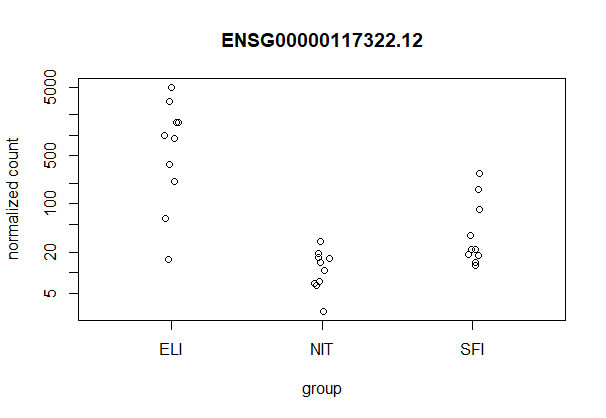

Figure 5.2: Gráficos de conteos del topgen entre ELI-NIT (ENSG00000117322) normalizados sobre cada grupo.

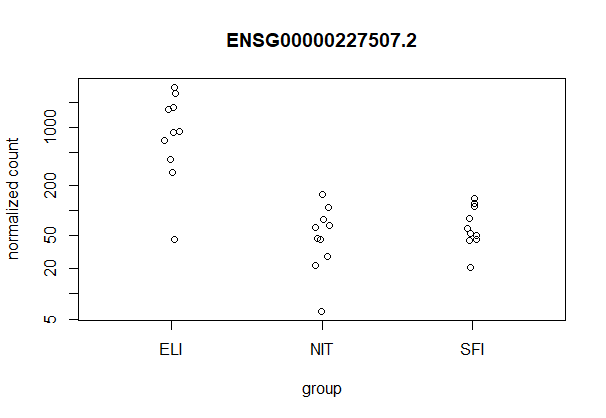

Figure 5.3: Gráficos de conteos del topgen entre ELI-SFI (ENSG00000227507) normalizados sobre cada grupo.

```r
topGeneresELI_SFI <- rownames(resELI_SFI)[which.min(resELI_SFI$padj)]
plotCounts(ddsMat, gene = topGeneresELI_SFI, intgroup=c("Group"))
```

# 6 Post-procesado de las listas de genes obtenidas

## 6.1 Anotación de resultados

Nuestras tablas de resultados contienen los identificadores de genes de Ensembl, pero los nombres de los genes podrían darnos más información que nos permita interpretar los resultados obtenidos. Bioconductor tiene varios paquetes que permiten la anotación de genes, por ejemplo, el paquete *AnnotationDbi* y el paquete de anotación *org.Hs.eg.db*.

```r
library("AnnotationDbi")
library("org.Hs.eg.db")
```

Este es el paquete de anotación de organismos (“org”) para *Homo sapiens* (“Hs”), organizado como un paquete *AnnotationDbi* de base de datos (“db”), usando identificadores de genes Entrez (“eg”) como clave primaria. Para obtener una lista de todas las claves disponible utilizamos el siguiente código:

```r
columns(org.Hs.eg.db)
```

```
##  [1] "ACCNUM"       "ALIAS"        "ENSEMBL"      "ENSEMBLPROT"  "ENSEMBLTRANS"
##  [6] "ENTREZID"     "ENZYME"       "EVIDENCE"     "EVIDENCEALL"  "GENENAME"
## [11] "GO"           "GOALL"        "IPI"          "MAP"          "OMIM"
## [16] "ONTOLOGY"     "ONTOLOGYALL"  "PATH"         "PFAM"         "PMID"
## [21] "PROSITE"      "REFSEQ"       "SYMBOL"       "UCSCKG"       "UNIGENE"
## [26] "UNIPROT"
```

Podemos utilizar la función *mapIds* para añadir columnas individuales a nuestra tabla de resultados. Utilizaremos el nombre de las filas de la tabla de resultados como clave y específicamos a la función `keytype=ENSEMBL`. El argumento columna le dice a la función *mapIds* la información que queremos y el argumento `multiVals` le dice la función qué hacer si hay múltiples valores posibles para un único valor de input.

**SFI-NIT**

```r
SFI_NITens.str <- substr(rownames(resSFI_NIT), 1, 15)
resSFI_NIT$symbol <- mapIds(org.Hs.eg.db,
                     keys=SFI_NITens.str,
                     column="SYMBOL",
                     keytype="ENSEMBL",
                     multiVals="first")
resSFI_NIT$entrez <- mapIds(org.Hs.eg.db,
                     keys=SFI_NITens.str,
                     column="ENTREZID",
                     keytype="ENSEMBL",
                     multiVals="first")
```

**ELI-NIT**

```r
ELI_NITens.str <- substr(rownames(resELI_NIT), 1, 15)
resELI_NIT$symbol <- mapIds(org.Hs.eg.db,
                     keys=ELI_NITens.str,
                     column="SYMBOL",
                     keytype="ENSEMBL",
                     multiVals="first")
resELI_NIT$entrez <- mapIds(org.Hs.eg.db,
                     keys=ELI_NITens.str,
                     column="ENTREZID",
                     keytype="ENSEMBL",
                     multiVals="first")
```

**ELI-SFI**

```r
ELI_SFIens.str <- substr(rownames(resELI_SFI), 1, 15)
resELI_SFI$symbol <- mapIds(org.Hs.eg.db,
                     keys=ELI_SFIens.str,
                     column="SYMBOL",
                     keytype="ENSEMBL",
                     multiVals="first")
resELI_SFI$entrez <- mapIds(org.Hs.eg.db,
                     keys=ELI_SFIens.str,
                     column="ENTREZID",
                     keytype="ENSEMBL",
                     multiVals="first")
```

Ahora ya tenemos los resultados de los genes con su símbolo (nombre corto del gen) y su identificador de entrez.

**SFI-NIT**

```r
resSFI_NITOrdered <- resSFI_NIT[order(resSFI_NIT$pvalue),]
head(resSFI_NITOrdered)
```

```
## log2 fold change (MLE): Group SFI vs NIT
## Wald test p-value: Group SFI vs NIT
## DataFrame with 6 rows and 8 columns
##                           baseMean   log2FoldChange             lfcSE
##                          <numeric>        <numeric>         <numeric>
## ENSG00000211937.2  597.65311348055  9.0548038287817  1.10778352757519
## ENSG00000211685.2 835.959103455392 9.60191734819233   1.1926692697903
## ENSG00000132465.6  7698.6559873005 6.33096657740697  0.80586726924097
## ENSG00000211673.2  1301.9974533701 7.98221850515508  1.01904405814421
## ENSG00000211941.2 576.133426614737 8.65375848598596  1.10750151557592
## ENSG00000211660.3 1915.17139538082 7.37722015007504 0.959383462776179
##                               stat               pvalue                 padj
##                          <numeric>            <numeric>            <numeric>
## ENSG00000211937.2 8.17380255563253 2.98818694451045e-16 8.15027989115226e-12
## ENSG00000211685.2 8.05077953411223 8.22683470467297e-16 1.12193458284978e-11
## ENSG00000132465.6 7.85609097062594 3.96307286893978e-15 3.02773117293486e-11
## ENSG00000211673.2  7.8330455306236 4.76191765529738e-15 3.02773117293486e-11
## ENSG00000211941.2 7.81376672110993 5.55037795221788e-15 3.02773117293486e-11
## ENSG00000211660.3 7.68954274938979 1.47661792244207e-14 6.71245897243459e-11
##                        symbol      entrez
##                   <character> <character>
## ENSG00000211937.2          NA          NA
## ENSG00000211685.2          NA          NA
## ENSG00000132465.6      JCHAIN        3512
## ENSG00000211673.2          NA          NA
## ENSG00000211941.2          NA          NA
## ENSG00000211660.3          NA          NA
```

**ELI-NIT**

```r
resELI_NITOrdered <- resELI_NIT[order(resELI_NIT$pvalue),]
head(resELI_NITOrdered)
```

```
## log2 fold change (MLE): Group ELI vs NIT
## Wald test p-value: Group ELI vs NIT
## DataFrame with 6 rows and 8 columns
##                            baseMean   log2FoldChange             lfcSE
##                           <numeric>        <numeric>         <numeric>
## ENSG00000117322.12 478.741920641574 6.78407893913362 0.649129131070922
## ENSG00000167483.13 566.439655574536 6.28964058715963 0.614394532941478
## ENSG00000177455.7  711.711499551166 7.36347029995621 0.749872875787113
## ENSG00000160856.16 485.074551183862 5.63517358708714 0.580374994547574
## ENSG00000083454.17 879.935416387597 6.19593837981244 0.639632006718331
## ENSG00000269404.2  240.654290415454 5.59562223400271 0.597603447638916
##                                stat               pvalue                 padj
##                           <numeric>            <numeric>            <numeric>
## ENSG00000117322.12 10.4510468170507 1.44916747653167e-25 4.43793048013057e-21
## ENSG00000167483.13 10.2371363186572 1.35178299527589e-24 2.06985012236644e-20
## ENSG00000177455.7   9.8196248160424 9.26878602199004e-23 9.46157677124744e-19
## ENSG00000160856.16 9.70953890161996 2.74576408794227e-22  2.1021569857286e-18
## ENSG00000083454.17  9.6867234827742 3.43367570055829e-22 2.10305769307794e-18
## ENSG00000269404.2  9.36343700176191  7.7184172688998e-21 3.85728112396491e-17
##                         symbol      entrez
##                    <character> <character>
## ENSG00000117322.12         CR2        1380
## ENSG00000167483.13      NIBAN3      199786
## ENSG00000177455.7         CD19         930
## ENSG00000160856.16       FCRL3      115352
## ENSG00000083454.17       P2RX5        5026
## ENSG00000269404.2         SPIB        6689
```

**ELI-SFI**

```r
resELI_SFIOrdered <- resELI_SFI[order(resELI_SFI$pvalue),]
head(resELI_SFIOrdered)
```

```
## log2 fold change (MLE): Group ELI vs SFI
## Wald test p-value: Group ELI vs SFI
## DataFrame with 6 rows and 8 columns
##                            baseMean   log2FoldChange             lfcSE
##                           <numeric>        <numeric>         <numeric>
## ENSG00000227507.2  446.791234770866 4.05754619855237 0.482447848231118
## ENSG00000204282.3  752.199673629595 2.45711276486685 0.311792000584089
## ENSG00000110665.7   332.31020546951 2.68974034723413 0.363471361722794
## ENSG00000239713.3  521.491092674325 1.48696037325345 0.205942528317325
## ENSG00000166803.6  83.0322470593783  1.7807502216107 0.247560646257027
## ENSG00000172794.15 344.925123496956 2.59836036074311 0.362604842690071
##                                stat               pvalue                 padj
##                           <numeric>            <numeric>            <numeric>
## ENSG00000227507.2  8.41033121699942 4.08854513723686e-17  1.1835929317787e-12
## ENSG00000204282.3  7.88061515453849 3.25773233100077e-15 4.71540466250707e-11
## ENSG00000110665.7  7.40014380908914 1.36037092744152e-13 1.31271259928348e-09
## ENSG00000239713.3  7.22026861281552 5.18849836770377e-13 3.66469920694286e-09
## ENSG00000166803.6  7.19318780482522 6.32957823576437e-13 3.66469920694286e-09
## ENSG00000172794.15 7.16581814370307 7.73233627068647e-13 3.73072337833504e-09
##                         symbol      entrez
##                    <character> <character>
## ENSG00000227507.2          LTB        4050
## ENSG00000204282.3   TNRC6C-AS1   100131096
## ENSG00000110665.7     C11orf21       29125
## ENSG00000239713.3     APOBEC3G       60489
## ENSG00000166803.6        PCLAF        9768
## ENSG00000172794.15       RAB37      326624
```

Si nos fijamos en la tabla de la comparación SFI-NIT muchas de las entradas nos aparecen con NAs tras la anotación (tanto en la columna Symbol como en la columna de entrez). Sin embargo, esto no lo observamos en las otras dos comparaciones. Esto puede ser debido a que, como ya hemos visto anteriormente la comparación SFI-NIT es en la que se veían menos genes diferencialmente expresados.

### 6.1.1 Exportando resultados

Podemos exportar los resultados en formato CSV y así poder verlos en programas como Excel. Para ello, primero tendremos que convertir la tabla de resultados en un objeto tipo Dataframe y luego podemos procesarlo con la función *write.csv*.

**SFI-NIT**

```r
resSFI_NITOrderedDF <- as.data.frame(resSFI_NIT)[1:100, ]
write.csv(resSFI_NITOrderedDF, file=file.path(resultsDir, "resSFI_NITOrderedDF.csv"))
```

**ELI-NIT**

```r
resELI_NITOrderedDF <- as.data.frame(resELI_NIT)[1:100, ]
write.csv(resELI_NITOrderedDF, file=file.path(resultsDir, "resELI_NITOrderedDF.csv"))
```

**ELI-SFI**

```r
resELI_SFIOrderedDF <- as.data.frame(resELI_SFI)[1:100, ]
write.csv(resELI_SFIOrderedDF, file=file.path(resultsDir, "resELI_SFIOrderedDF.csv"))
```

## 6.2 Visualización de los perfiles de expresión

Tras seleccionar los genes diferencialmente expresados podemos visualizar las expresiones up o down reguladas mediante mapas de color o *Heatmaps*. Primero tendremos que seleccionar los genes a visualizar.

En la Figura 6.1 encontramos un mapa de color en el que podemos ver las 30 muestras diferenciadas según su grupo y su sexo y los 20 genes con mayor varianza entre muestras. Podemos ver con los colores los genes que están regulados positivamente (color rojo) o negativamente (color azul) en cada una de las muestras. Además, estas se agrupan de acuerdo a el parecido entre sí. Es curioso ver que sí que hay genes que se expresan de forma diferencial entre hombres y mujeres a pesar de pertenecer al mismo grupo.

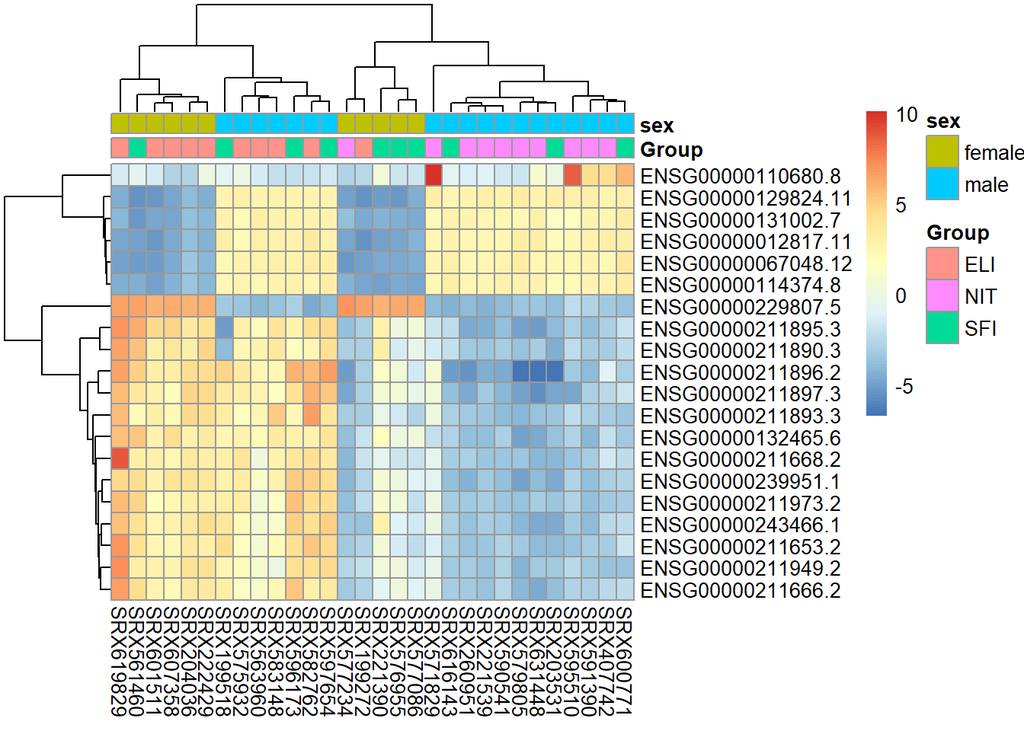

Figure 6.1: Mapa de color de los valores transformados por VST en todas las muestras.

```r
library("genefilter")
library("SummarizedExperiment")
topVarGenes <- head(order(rowVars(assay(vsd)), decreasing = TRUE), 20)
mat  <- assay(vsd)[ topVarGenes, ]
mat  <- mat - rowMeans(mat)
anno <- as.data.frame(colData(vsd)[, c("Group","sex")])
pheatmap(mat, annotation_col = anno)
```

## 6.3 Análisis de la significación biológica (1): Análisis de enriquecimiento

Los análisis de significación biológica buscan establecer qué funciones de los genes de la lista de genes obtenida se observan con más frecuencia. En este trabajo llevaremos a cabo un análisis básico de enriquecimiento utilizando el paquete `GOstats` de Bioconductor.

```r
require(annotate)
require(hgu133a.db)
require(GOstats)
listOfTables <- list(SFIVsNIT = resSFI_NITOrderedDF, ELIVsNIT = resELI_NITOrderedDF, ELIVsSFI = resELI_SFIOrderedDF)
for (i in 1:length(listOfTables))
# Seleccionamos la "topTable"
topTab <- listOfTables[[i]]
# Definimos el universo de genes: todos los que se han incluido en el análisis
# EL programa trabaja con identificadores "entrez" y no admite duplicados
entrezUniverse = unique(getEG(topTab["entrez"], "hgu133a.db"))
# Escogemos los grupos de sondas a incluir en el análisis
# Este análisis trabaja bien con varios centenares de genes
# por lo que es habitual basarse en p-valores sin ajustar para incluirlos
whichGenes<-topTab["padj"]<0.05
geneIds <- unique(entrezUniverse[whichGenes])
# Creamos los "hiperparámetros" en que se basa el análisis
GOparams = new("GOHyperGParams",
geneIds=geneIds, universeGeneIds=entrezUniverse,
annotation="org.Hs.eg.db", ontology="BP",
pvalueCutoff=0.001, conditional=FALSE,
testDirection="over")
# KEGGparams = new("KEGGHyperGParams",
# geneIds=geneIds, universeGeneIds=entrezUniverse,
# annotation="org.Hs.eg.db",
# pvalueCutoff=0.01, testDirection="over")
# Ejecutamos los análisis
GOhyper = hyperGTest(GOparams)
# KEGGhyper = hyperGTest(KEGGparams)
# Creamos un informe html con los resultados
comparison = names(listOfTables)[i]
GOfilename =file.path(resultsDir,
paste("GOResults.",comparison,".html", sep=""))
# KEGGfilename =file.path(resultsDir,
# paste("KEGGResults.",comparison,".html", sep=""))
htmlReport(GOhyper, file = GOfilename, summary.args=list("htmlLinks"=TRUE))
# htmlReport(KEGGhyper, file = KEGGfilename, summary.args=list("htmlLinks"=TRUE))
```

# 7 Discusión

En esta PEC hemos conseguido realizar un análisis de unos datos de RNA-seq, obteniendo los genes diferencialmente expresados para tres comparaciones distintas, de tres grupos. Sin embargo, no he conseguido realizar el análisis de significación biológica porque en las listas de genes con códigos entrez encontrábamos varios NA’s y otros problemas de código.

Hay varias cosas interesantes a destacar de este análisis. La normalización de los datos la hemos realizado con Variance Stabilizing Transformation (VST) porque no cogía los datos de los genes con pocos conteos que podrían producir ruido en nuestro análisis.

De los grupos analizados parece que el grupo SFI-NIT son más parecidos entre sí que cualquiera de estos dos con ELI dado que encontramos menos genes diferencialmente expresados. También hemos encontrado a la hora de realizar los heatmaps de los genes que el sexo parece influir en la expresión génica.

Hemos conseguido anotar los genes resultantes por símbolo y número de identificación de entrez, sin embargo, parece que hay problemas a la hora de realizar esta anotación para los genes de la comparación SFI-NIT.

En general, las mayores diferencias en cuanto a la expresión de genes se encuentran entre el grupo Extensive lymphoid infiltrates (ELI) con los otros dos grupos.

# Bibliografía

Oshlack, Alicia, Mark Robinson, and Matthew Young. 2010. “From Rna-Seq Reads to Differential Expression Results.” *Genome Biology* 11 (December): 220. https://doi.org/10.1186/gb-2010-11-12-220.

Pobre, Vânia, and Cecília M. Arraiano. 2018. “Characterizing the Role of Exoribonucleases in the Control of Microbial Gene Expression: Differential Rna-Seq.” *Methods in Enzymology High-Density Sequencing Applications in Microbial Molecular Genetics*, 1–24. https://doi.org/10.1016/bs.mie.2018.08.010.

“Rna-Seq Workflow: Gene-Level Exploratory Analysis and Differential Expression.” n.d. *RNA-Seq Workflow: Gene-Level Exploratory Analysis and Differential Expression*. http://master.bioconductor.org/packages/release/workflows/vignettes/rnaseqGene/inst/doc/rnaseqGene.html#aligning-reads-to-a-reference-genome.

Wang, Zhong, Mark Gerstein, and Michael Snyder. 2009. “RNA-Seq: A Revolutionary Tool for Transcriptomics.” *Nature Reviews Genetics* 10 (1): 57–63. https://doi.org/10.1038/nrg2484.